# 6. ARIMA Modeling

# (6-3) MODEL SELECTION

[Nao Mimoto](https://nmimoto.github.io/) - [Dept. of Statistics](http://www.uakron.edu/stat/) : [The University of Akron](http://www.uakron.edu)

[TS Class Web Page](https://nmimoto.github.io/477/) – [R resource page](https://nmimoto.github.io/R/)

# 1. Examples of ARIMA fitting

## ARIMA(p,d,q) model

Your observation $Y_t$ is modeled as ARIMA(p,d,q) if:

- Take difference $d$ times. Call it $X_t$.
  $$\bigtriangledown^d Y_t \hspace{3mm} = \hspace{3mm} X_t$$
- Then model $X_t$ with ARMA(p,q) model:
  $$\Phi(B) \, X_t \hspace{3mm} = \hspace{3mm} \Theta(B) \, e_t$$
  where $e_t\sim WN(0,\sigma^2)$.

ARIMA(p,d,q) model means you difference the data $d$ times, then you get ARMA($p,q$).

## Ex: Sheep Data

Annual sheep population (1000s) in England and Wales 1867 – 1939

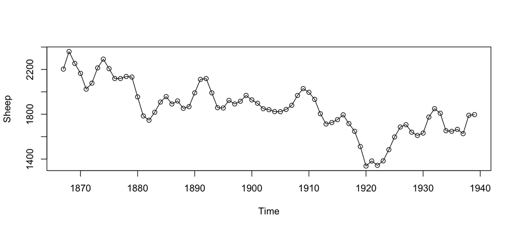

```r
  library(forecast)
  source('https://nmimoto.github.io/R/TS-00.txt')

  D  <- read.csv("https://nmimoto.github.io/datasets/sheep.csv", header=T)
  Sheep <- ts(D[,2], start=c(1867), freq=1)

  plot(Sheep, type="o")
```

```r
  Stationarity.tests(Sheep)
```

```
##        KPSS   ADF    PP
## p-val: 0.01 0.554 0.211
```

```r
  #--- ARIMA fit ---
  Fit1 <- auto.arima(Sheep, stepwise=FALSE, approximation=FALSE)
  Fit1
```

```
## Series: Sheep
## ARIMA(3,1,0)
##
## Coefficients:
##          ar1      ar2      ar3
##       0.4210  -0.2018  -0.3044
## s.e.  0.1193   0.1363   0.1243
##
## sigma^2 estimated as 4991:  log likelihood=-407.56
## AIC=823.12   AICc=823.71   BIC=832.22
```

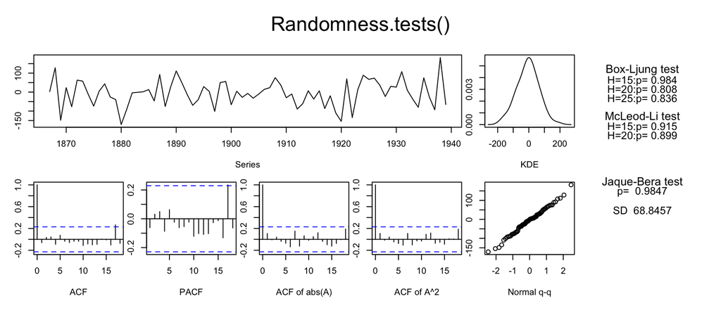

```
##   B-L test H0: the sereis is uncorrelated
##   M-L test H0: the square of the sereis is uncorrelated
##   J-B test H0: the sereis came from Normal distribution
##   SD         : Standard Deviation of the series
```

```
##       BL15  BL20  BL25  ML15  ML20    JB     SD
## [1,] 0.984 0.808 0.836 0.915 0.899 0.985 68.846
```

```r
  Randomness.tests(Fit1$resid)
```

- $Y_t$ is ARIMA(3,1,0) without drift
  $$\bigtriangledown Y_t \hspace{3mm} = \hspace{3mm} X_t \\$$
- $X_t$ is ARMA(3,0)
  $$X_t - \phi_1 X_{t-1} - \phi_2 X_{t-2} - \phi_3 X_{x-3} = e_t$$
- This could mean two things
  $$Y_t \hspace{3mm} = \hspace{3mm} a + b t + S_t \\ \\
  Y_t \hspace{3mm} = \hspace{3mm} M_t + S_t$$
  $S_t$ is stationary series. $M_t$ is Random Walk with drift $\delta$.

```r
  Fit1     # Estimates of parameters
```

```
## Series: Sheep
## ARIMA(3,1,0)
##
## Coefficients:
##          ar1      ar2      ar3
##       0.4210  -0.2018  -0.3044
## s.e.  0.1193   0.1363   0.1243
##
## sigma^2 estimated as 4991:  log likelihood=-407.56
## AIC=823.12   AICc=823.71   BIC=832.22
```

## Sheep: Doing the same by hand

Let’s open up above Sheep data analysis, and take difference by hand.

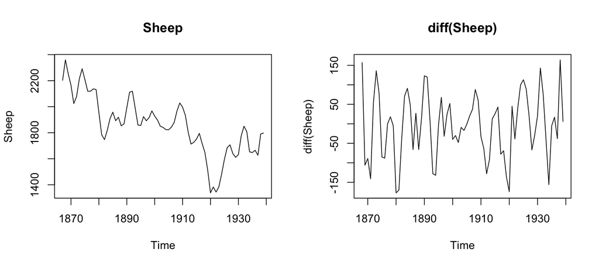

```r
  layout(matrix(1:2, 1, 2))
  plot(Sheep, main="Sheep")
  plot(diff(Sheep), main="diff(Sheep)")
```

```r
  Stationarity.tests(diff(Sheep))
```

```
##        KPSS   ADF   PP
## p-val:  0.1 0.022 0.01
```

```r
  Fit2 <- auto.arima(diff(Sheep), stepwise=FALSE, approximation=FALSE)
  Fit2
```

```
## Series: diff(Sheep)
## ARIMA(3,0,0) with zero mean
##
## Coefficients:
##          ar1      ar2      ar3
##       0.4210  -0.2018  -0.3044
## s.e.  0.1193   0.1363   0.1243
##
## sigma^2 estimated as 4991:  log likelihood=-407.56
## AIC=823.12   AICc=823.71   BIC=832.22
```

## Sheep: Lenear Trend or Random Trend

```r
  Reg1 =  lm(Sheep ~ time(Sheep))
  summary(Reg1)
```

```
##
## Call:
## lm(formula = Sheep ~ time(Sheep))
##
## Residuals:
##     Min      1Q  Median      3Q     Max
## -380.54  -67.68   16.21   77.20  232.84
##
## Coefficients:
##               Estimate Std. Error t value Pr(>|t|)
## (Intercept) 17319.1627  1502.3855   11.53  < 2e-16 ***
## time(Sheep)    -8.1253     0.7894  -10.29 1.01e-15 ***
## ---
## Signif. codes:  0 '***' 0.001 '**' 0.01 '*' 0.05 '.' 0.1 ' ' 1
##
## Residual standard error: 142.1 on 71 degrees of freedom
## Multiple R-squared:  0.5987, Adjusted R-squared:  0.5931
## F-statistic: 105.9 on 1 and 71 DF,  p-value: 1.01e-15
```

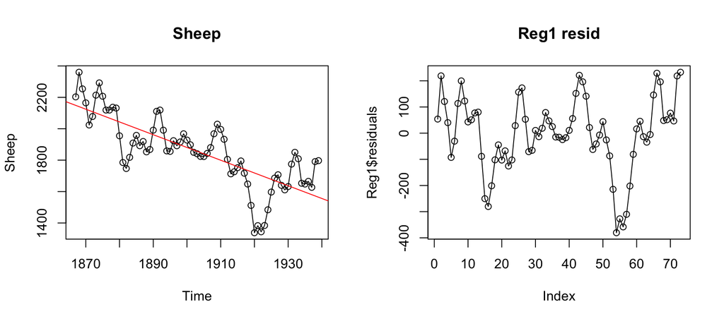

```r
  layout(matrix(1:2, 1, 2))
  plot(Sheep, type="o", main="Sheep")
  abline(Reg1, col="red")

  plot(Reg1$residuals, type="o", main="Reg1 resid")
```

```r
  Stationarity.tests(Reg1$residuals)
```

```
##        KPSS   ADF    PP
## p-val:  0.1 0.554 0.211
```

- After taking the linear trend out, it is quetionable that residuals are stationary.
- Sheep should be modeled by random trend instead of linear trend.

### 2nd look

```r
  Fit11 <- Arima(Sheep, order=c(3,1,0), include.drift=TRUE)
  Fit11
```

```
## Series: Sheep
## ARIMA(3,1,0) with drift
##
## Coefficients:
##          ar1      ar2      ar3    drift
##       0.4134  -0.2045  -0.3115  -5.8707
## s.e.  0.1192   0.1357   0.1241   7.4553
##
## sigma^2 estimated as 5021:  log likelihood=-407.26
## AIC=824.51   AICc=825.42   BIC=835.9
```

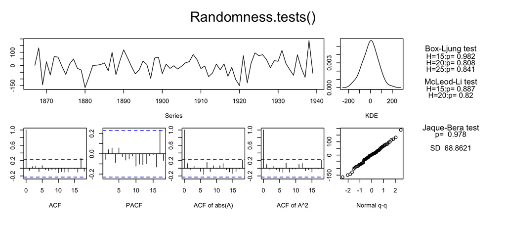

```
##   B-L test H0: the sereis is uncorrelated
##   M-L test H0: the square of the sereis is uncorrelated
##   J-B test H0: the sereis came from Normal distribution
##   SD         : Standard Deviation of the series
```

```
##       BL15  BL20  BL25  ML15 ML20    JB     SD
## [1,] 0.982 0.808 0.841 0.887 0.82 0.978 68.862
```

```r
  Randomness.tests(Fit11$residuals)
```

```r
  Stationarity.tests(Fit11$residuals)
```

```
##        KPSS   ADF   PP
## p-val:  0.1 0.071 0.01
```

```r
  Fit12 <- auto.arima(Sheep, d=0, xreg=time(Sheep), stepwise=FALSE, approximation=FALSE)
  Fit12
```

```
## Series: Sheep
## Regression with ARIMA(0,0,3) errors
##
## Coefficients:
##          ma1     ma2     ma3  intercept     xreg
##       1.3047  1.0666  0.5598   16215.86  -7.5449
## s.e.  0.1085  0.1295  0.1150    2588.70   1.3603
##
## sigma^2 estimated as 4606:  log likelihood=-410.04
## AIC=832.07   AICc=833.35   BIC=845.82
```

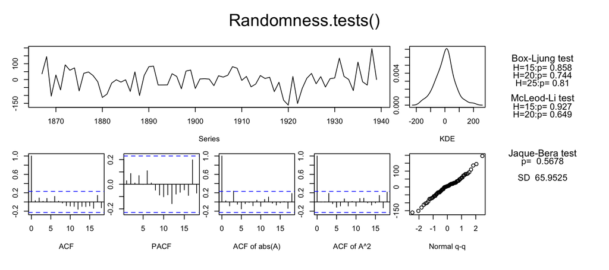

```
##   B-L test H0: the sereis is uncorrelated
##   M-L test H0: the square of the sereis is uncorrelated
##   J-B test H0: the sereis came from Normal distribution
##   SD         : Standard Deviation of the series
```

```
##       BL15  BL20 BL25  ML15  ML20    JB     SD
## [1,] 0.858 0.744 0.81 0.927 0.649 0.568 65.952
```

```r
  Randomness.tests(Fit12$residuals)
```

- Fitting a line and fitting ARMA(0,3) seems to be ok, since residuals are uncorrelated. However, the stationarity is questionable.
- Fitting ARIMA(3,1,0) with drift, shows non-significant drift term. If linear trend is correct, then drift term should match the slope term.
- ARIMA(3,1,0) fit is suggesting the random trend without drift.

# 2. ARIMA(p,d,q) Model Selection

## Model Selection in ARIMA($p,d,q$)

- Use stationarity test to decide how many times to defference ($d$).
- When AR(1) parameter is estimated, see if $\phi_1$ is significantly different from 1. (under differencing)
- Watch for sign of overdifferencing.
- CANNOT use AICc to compare between models with different $d$.

### auto.arima() algorighm

Hyndman-Khandakar algorithm for automatic ARIMA modelling in

- The number of differences $d$ is determined using repeated KPSS tests.
- The values of $p$ and $q$ are then chosen by minimizing the AICc after differencing the data $d$ times. Rather than considering every possible combination of $p$ and $q$, the algorithm uses a stepwise search to traverse the model space.
  - The best model (with smallest AICc) is selected from the following four:

    ARIMA(2,d,2), ARIMA(0,d,0), ARIMA(1,d,0), ARIMA(0,d,1).

    If $d=0$ then the constant $c$ is included; if $d \> 1$ then the constant $c$ is set to zero. This is called the “current model”.
  - Variations on the current model are considered:

    vary $p$ and/or $q$ from the current model by $\pm 1$; include/exclude $c$ from the current model. The best model considered so far (either the current model, or one of these variations) becomes the new current model.
  - Repeat Step above until no lower AICc can be found.

### After auto.arima()

- Check parameter significance. If parameters are not significant, then remove from the model.
- For value of $d$ selected by **auto.arima()**, take the difference by hand, and use **Stationarity.tests()** to see what other tests say.
- You can change stationarity test used by **auto.arima()**. Default is KPSS test.  
  Type **?auto.arima** to see syntax of how to change default.

## Overdifferencing

- Suppose $\delta X_t = Y_t$
  $$Y_t \hspace{3mm} = \hspace{3mm} e_t$$
- Each step has now little more change of being positive than negative.
  $$P(e_t >0) = .54 \hspace{10mm} P(e_t \leq 0) = .46.$$
- Take $\bigtriangledown$ again, then you get
  $$\bigtriangledown Y_t = e_t - e_{t-1}$$
  Now we got MA(1) with $\theta_1 = 1$. That’s not invertible.
- Suppose
  $$\bigtriangledown X_t \hspace{3mm} = \hspace{3mm} Y_t\\ \\
  Y_t \hspace{3mm} = \hspace{3mm} e_t - \theta_1 e_{t-1}$$
  If you take $\bigtriangledown$ again,
  $$\bigtriangledown Y_t \hspace{3mm} = \hspace{3mm} (e_t - \theta_1 e_{t-1}) - (e_{t-1} - \theta_1 e_{t-2}) \\ \\
  \hspace{3mm} = \hspace{3mm} (e_t - (1+\theta_1) e_{t-1} + \theta_1 e_{t-2}) .$$
- So $\bigtriangledown Y_t$ is MA(2) with
  $$\Theta(z) \hspace{3mm} = \hspace{3mm} 1 - (1+\theta_1) z + \theta_1 z^2$$
  Root is

  $$\begin{align}
  \frac{-b \pm \sqrt{b^2\pm 4ac}}{2a}
  &= \hspace{3mm} \frac{(1+\theta_1) \pm \sqrt{(1+\theta_1)^2-4\theta_1}}{ 2\theta_1} \\ \\
  &= \hspace{3mm} \frac{(1+\theta_1) \pm \sqrt{1- 2 \theta_1 + \theta_1^2}}{ 2 \theta_1} \\ \\
  &= \hspace{3mm} \frac{(1+\theta_1) \pm \sqrt{(1- \theta_1)^2}}{ 2 \theta_1} \\ \\
  &= \hspace{3mm} \frac{2}{2 \theta_1} \hspace{3mm} \mbox{or} \hspace{3mm}
  \frac{2\theta_1}{2 \theta_1}
  \end{align}$$
  That’s a unit root!
- Testing Unit-Root in MA(q) polynomials $\to$ not fully resolved.
- Test Unit-Root in MA(1) $\to$ see if $\hat\theta_1$ is significantly different from -1.

## ARMA with same polynomials

- Suppose you have ARMA(1,1) with
  $$Y_t - .5 Y_{t-1} = e_t - .5 e_{t-1}$$
  Then this is

  $$\begin{align}
  (1-.5 B) Y_t
  &= \hspace{3mm} (1-.5 B) e_t \\\\
  &= \hspace{3mm} e_t
  \end{align}$$

So $Y_t$ is just a white noise.

- larain in package TSA is good example for this.

## Ex: LArain data

Check for same characteristic polynomials.

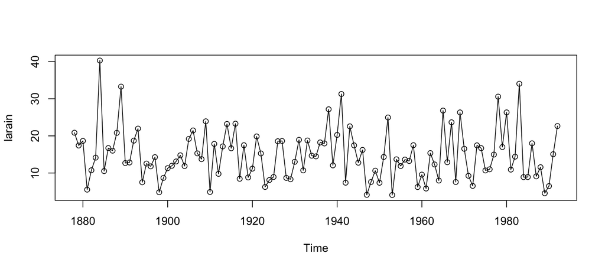

```r
  library(forecast)
  source('https://nmimoto.github.io/R/TS-00.txt')

  acf.orig <- acf;  library(TSA);  acf <- acf.orig

  data(larain)

  plot(larain, type="o")
```

```r
  Arima(larain, order=c(1,0,1))
```

```
## Series: larain
## ARIMA(1,0,1) with non-zero mean
##
## Coefficients:
##           ar1     ma1     mean
##       -0.3402  0.3006  14.8848
## s.e.   0.9121  0.9185   0.6196
##
## sigma^2 estimated as 48.1:  log likelihood=-384.38
## AIC=776.76   AICc=777.12   BIC=787.74
```

- When orders of AR and MA mathces, watch out for equal value of parameters. It may indicate WN.
- If MA(1) gives you $-1$, it indicates the over-differencing.

# Summary

#### ARIMA(p,d,q) model means that difference was taken d times, then ARMA(p,q) model was fit.

#### **auto.arima()** uses KPSS test as a guide for choosing d automatically. It is always a good idea to use Stationarity.tests and see if the choice of d is reasonable.

#### If the series was over-differenced, force-fitting MA(1) produces $\hat \theta_1$ that is too close to -1.

#### If the series was under-differenced, force-fitting AR(1) gives $\hat \phi_1$ that is too close to $\pm 1$. You can also use Stationarity.tests() as a guide for under-differencing.

#### When polynomials of AR and MA are the same, it just mean that you got WN.

[TS Class Web Page](https://nmimoto.github.io/477/) – [R resource page](https://nmimoto.github.io/R/)